# Classify_Raster

Megan Cattau

June 21, 2016

# Classify a Raster using Threshold Values in R

We will classify a raster file using defined value ranges in R.

Load the required libraries.

```r
# load libraries
library(raster)
library(rhdf5)
library(rgdal)
# be sure to set your working directory
setwd("~/Documents/data/NEONDI-2016/Tues-am-LiDAR") # Mac

#source("/Users/lwasser/Documents/GitHub/neon-aop-package/neonAOP/R/aop-data.R")
```

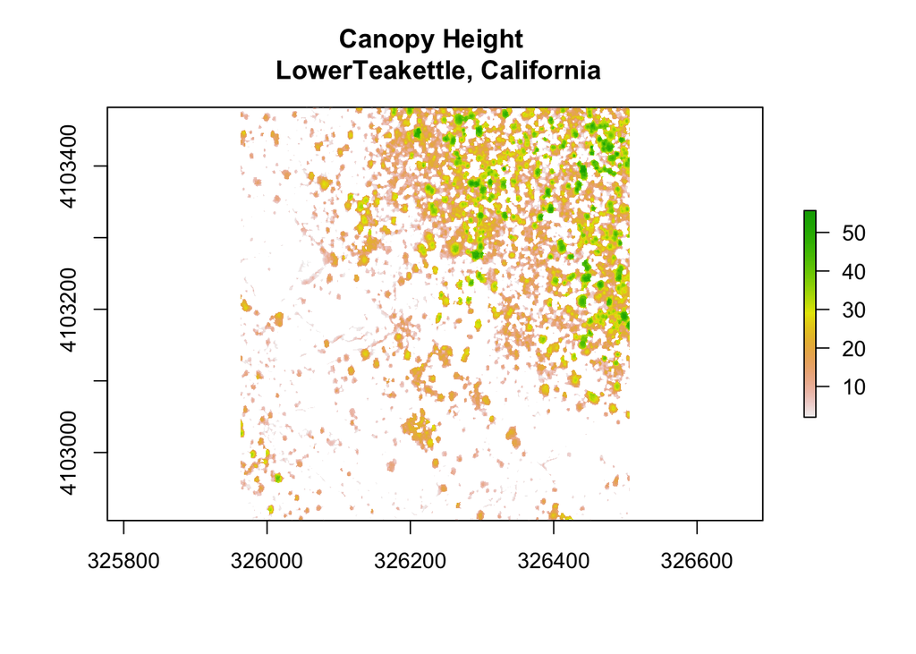

```r
# read LiDAR canopy height model
chm <- raster("../NEONdata/D17-California/TEAK/2013/lidar/TEAK_lidarCHM.tif")

# assign chm values of 0 to NA
chm[chm==0] <- NA

# do the values in the data look reasonable?
plot(chm,
     main="Canopy Height \n LowerTeakettle, California")
```

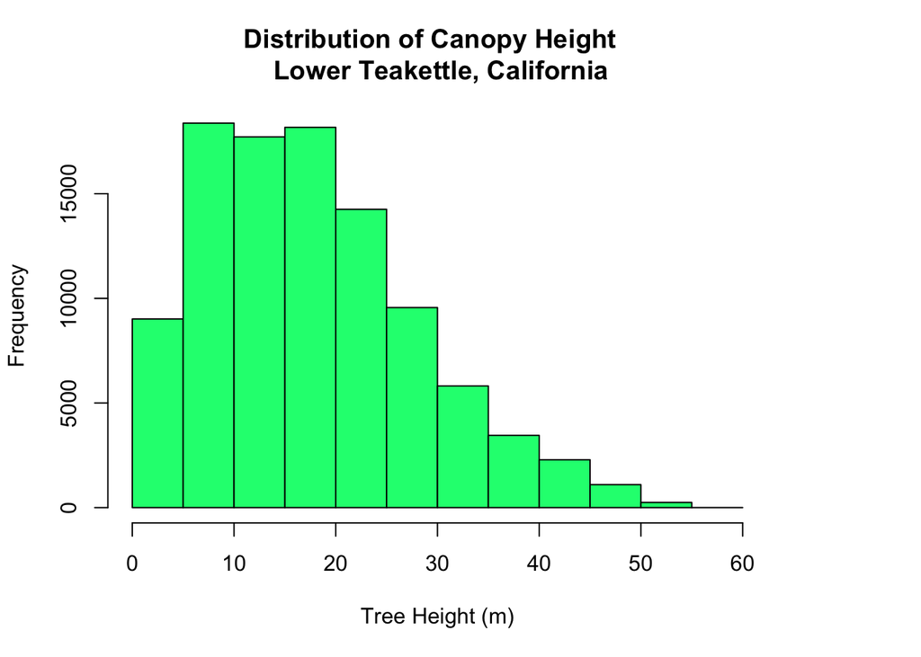

```r
hist(chm,
     main="Distribution of Canopy Height  \n Lower Teakettle, California",
     xlab="Tree Height (m)",
     col="springgreen")
```

Import Aspect Data Next, we’ll import an aspect dataset - one of the NEON data products.

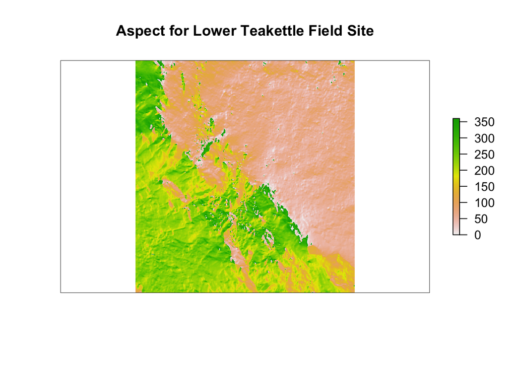

```r
# calculate aspect of cropped DTM if you'd like to compute it yourself
# aspect <- terrain(your-dem-or-terrain-data.tif, opt = "aspect", unit = "degrees", neighbors = 8)

# read in aspect .tif
aspect <- raster("../NEONdata/D17-California/TEAK/2013/lidar/TEAK_lidarAspect.tif")

plot(aspect,
     main="Aspect for Lower Teakettle Field Site",
     axes=F)
```

```r
# first create a matrix of values that represent the classification threshold ranges and the associated “class”
# Our range of values are as follows: We will assign all north facing slopes “1” and south facing “2”.
# North Facing Slopes: 0-45 degrees, 315-360 degrees; class=1
# South Facing Slopes: 135-225 degrees; class=2

class.m <- c(0, 45, 1,
             45, 135, NA,
             135, 225, 2,
             225 , 315, NA,
             315, 360, 1)
class.m
```

```
##  [1]   0  45   1  45 135  NA 135 225   2 225 315  NA 315 360   1
```

```r
# reshape the object into a matrix with columns and rows
rcl.m <- matrix(class.m,
                ncol=3,
                byrow=TRUE)
rcl.m
```

```
##      [,1] [,2] [,3]
## [1,]    0   45    1
## [2,]   45  135   NA
## [3,]  135  225    2
## [4,]  225  315   NA
## [5,]  315  360    1
```

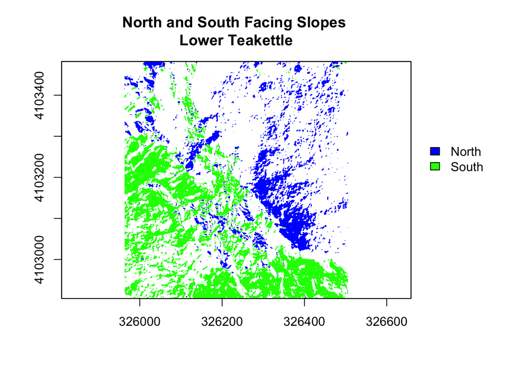

```r
# reclassify the raster rcl.m using the reclass function to create a new raster.
asp.ns <- reclassify(aspect,
                     rcl.m)

# plot outside of the plot region

# make room for a legend
par(xpd = FALSE, mar=c(5.1, 4.1, 4.1, 4.5))
# plot
plot(asp.ns,
     col=c("white","blue","green"), # hard code colors, unclassified (0)=white,
         #N (1) =blue, S(2)=green
     main="North and South Facing Slopes \nLower Teakettle",
     legend=F)
# allow legend to plot outside of bounds
par(xpd=TRUE)
# create the legend
legend((par()$usr[2] + 20), 4103300,  # set x,y legend location
       legend = c("North", "South"),  # make sure the order matches the colors, next
       fill = c("blue", "green"),
       bty="n") # turn off border
```

Export Classified Raster

```r
# export geotiff
writeRaster(asp.ns,
            filename="../outputs/TEAK/Teak_nsAspect2.tif",
            format="GTiff",
            options="COMPRESS=LZW",
            overwrite = TRUE,
            NAflag = -9999)
```

Mask a Raster using Threshold Values in R

```r
# load libraries
library(neonAOP)
```

Import LiDAR data

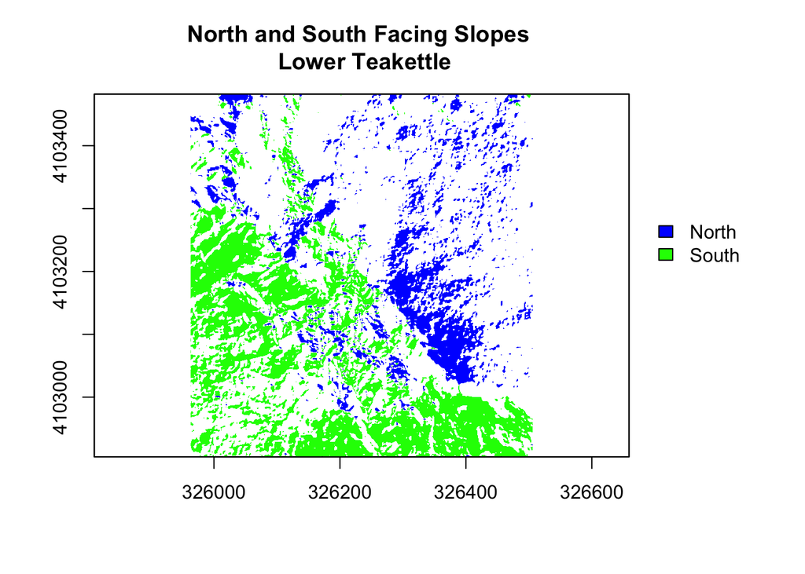

```r
# import aspect data from previous lesson
teak_nsAspect <- raster("../outputs/TEAK/TEAK_nsAspect2.tif")

# North facing slope = 1
# South facing slope = 2

# legend outside of the plot region
# make room for a legend
par(xpd = FALSE, mar=c(5.1, 4.1, 4.1, 4.5))

plot(teak_nsAspect,
     col=c("white","blue","green"),
     main="North and South Facing Slopes \n Lower Teakettle",
     legend=F)

# allow legend to plot outside of bounds
par(xpd=TRUE)

legend((par()$usr[2] + 20), 4103300, # set xy legend location
       legend = c("North", "South"),
       fill = c("blue", "green"),
       bty="n") # turn off border
```

Mask Data

Once we have created a threhold classified raster, we can use it for different things. One application is to use it as an analysis mask for another dataset.

Let’s try to find all pixels that have an NDVI value >.6 and are north facing.

We fist open NDVI

```r
# open NEON NDVI data
ndvi <- raster("../NEONdata/D17-California/TEAK/2013/spectrometer/veg_index/TEAK_NDVI.tif")
ndvi
```

```
## class       : RasterLayer
## dimensions  : 577, 543, 313311  (nrow, ncol, ncell)
## resolution  : 1, 1  (x, y)
## extent      : 325963, 326506, 4102905, 4103482  (xmin, xmax, ymin, ymax)
## coord. ref. : +proj=utm +zone=11 +datum=WGS84 +units=m +no_defs +ellps=WGS84 +towgs84=0,0,0
## data source : /Users/megancattau/Documents/data/NEONDI-2016/NEONdata/D17-California/TEAK/2013/spectrometer/veg_index/TEAK_NDVI.tif
## names       : TEAK_NDVI
## values      : -0.2252816, 0.9218391  (min, max)
```

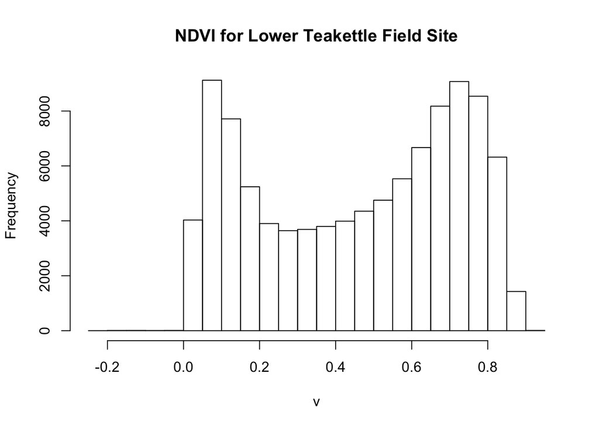

```r
hist(ndvi,
     main="NDVI for Lower Teakettle Field Site")
```

Exclude everything that’s not N facing or NDVI>.6 in the respective layers

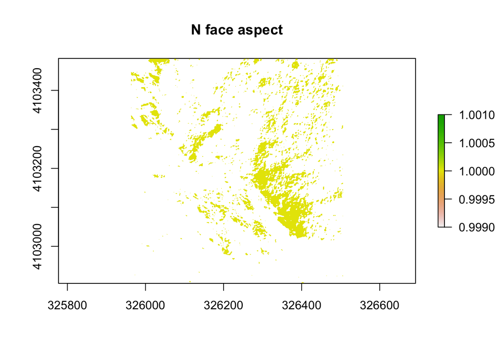

```r
# change values that are not N facing to NA
teak_nsAspect[teak_nsAspect!=1] <- NA
plot(teak_nsAspect,
     main="N face aspect")
```

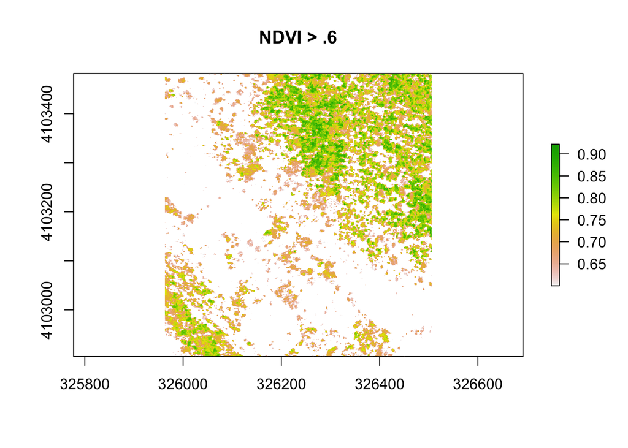

```r
# change values that are <.6 NDVI to NA
ndvi[ndvi<.6] <- NA
plot(ndvi,
     main="NDVI > .6")
```

Mask NDVI for N slopes

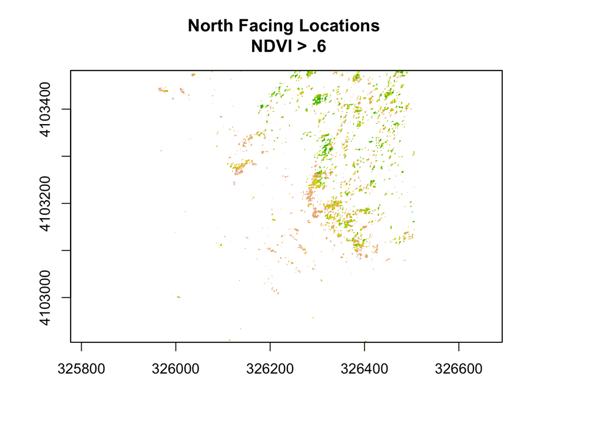

```r
# mask out only pixels that are north facing and NDVI >.6
# take NDVI layer and mask it with N facing slopes
nFacing.ndvi <- mask(ndvi, teak_nsAspect)
?mask

plot(nFacing.ndvi,
     main="North Facing Locations \n NDVI > .6",
     legend=F)
```